# Survival On the Titanic Using Stacked Ensemble

Lisa L Stuart

February 20, 2017

# 1 Intro

This is my second Kaggle script! I really wanted to improve my inital submission so I am choosing to explore and implement some ensemble methods and then pull them together in a stacking ensemble for better accuracy. Here goes!

## 1.1 Load Libraries

```r
# Load packages
library(plyr)
library('ggplot2') # visualization
library('ggthemes') # visualization
library('scales') # visualization
library('dplyr') # data manipulation
library('mice') # imputation
library('randomForest') # classification algorithm
```

## 1.2 Load Data

```r
train <- read.csv('C:/Users/Lisa/Desktop/DataScienceDegree/Portfolio Projects/TitanicSurvival/input/train.csv', stringsAsFactors = F)
test  <- read.csv('C:/Users/Lisa/Desktop/DataScienceDegree/Portfolio Projects/TitanicSurvival/input/test.csv', stringsAsFactors = F)

str(train)
```

```
## 'data.frame':    891 obs. of  12 variables:
##  $ PassengerId: int  1 2 3 4 5 6 7 8 9 10 ...
##  $ Survived   : int  0 1 1 1 0 0 0 0 1 1 ...
##  $ Pclass     : int  3 1 3 1 3 3 1 3 3 2 ...
##  $ Name       : chr  "Braund, Mr. Owen Harris" "Cumings, Mrs. John Bradley (Florence Briggs Thayer)" "Heikkinen, Miss. Laina" "Futrelle, Mrs. Jacques Heath (Lily May Peel)" ...
##  $ Sex        : chr  "male" "female" "female" "female" ...
##  $ Age        : num  22 38 26 35 35 NA 54 2 27 14 ...
##  $ SibSp      : int  1 1 0 1 0 0 0 3 0 1 ...
##  $ Parch      : int  0 0 0 0 0 0 0 1 2 0 ...
##  $ Ticket     : chr  "A/5 21171" "PC 17599" "STON/O2. 3101282" "113803" ...
##  $ Fare       : num  7.25 71.28 7.92 53.1 8.05 ...
##  $ Cabin      : chr  "" "C85" "" "C123" ...
##  $ Embarked   : chr  "S" "C" "S" "S" ...
```

```r
str(test)
```

```
## 'data.frame':    418 obs. of  11 variables:
##  $ PassengerId: int  892 893 894 895 896 897 898 899 900 901 ...
##  $ Pclass     : int  3 3 2 3 3 3 3 2 3 3 ...
##  $ Name       : chr  "Kelly, Mr. James" "Wilkes, Mrs. James (Ellen Needs)" "Myles, Mr. Thomas Francis" "Wirz, Mr. Albert" ...
##  $ Sex        : chr  "male" "female" "male" "male" ...
##  $ Age        : num  34.5 47 62 27 22 14 30 26 18 21 ...
##  $ SibSp      : int  0 1 0 0 1 0 0 1 0 2 ...
##  $ Parch      : int  0 0 0 0 1 0 0 1 0 0 ...
##  $ Ticket     : chr  "330911" "363272" "240276" "315154" ...
##  $ Fare       : num  7.83 7 9.69 8.66 12.29 ...
##  $ Cabin      : chr  "" "" "" "" ...
##  $ Embarked   : chr  "Q" "S" "Q" "S" ...
```

```r
full  <- bind_rows(train, test) # bind training & test data

# check data
str(full)
```

```
## 'data.frame':    1309 obs. of  12 variables:
##  $ PassengerId: int  1 2 3 4 5 6 7 8 9 10 ...
##  $ Survived   : int  0 1 1 1 0 0 0 0 1 1 ...
##  $ Pclass     : int  3 1 3 1 3 3 1 3 3 2 ...
##  $ Name       : chr  "Braund, Mr. Owen Harris" "Cumings, Mrs. John Bradley (Florence Briggs Thayer)" "Heikkinen, Miss. Laina" "Futrelle, Mrs. Jacques Heath (Lily May Peel)" ...
##  $ Sex        : chr  "male" "female" "female" "female" ...
##  $ Age        : num  22 38 26 35 35 NA 54 2 27 14 ...
##  $ SibSp      : int  1 1 0 1 0 0 0 3 0 1 ...
##  $ Parch      : int  0 0 0 0 0 0 0 1 2 0 ...
##  $ Ticket     : chr  "A/5 21171" "PC 17599" "STON/O2. 3101282" "113803" ...
##  $ Fare       : num  7.25 71.28 7.92 53.1 8.05 ...
##  $ Cabin      : chr  "" "C85" "" "C123" ...
##  $ Embarked   : chr  "S" "C" "S" "S" ...
```

```r
unique(full$Survived) # values are 1, 0, and NA (for the missing Survived row in test)
```

```
## [1]  0  1 NA
```

We can see the full dataset contains 1309 observations.

| Variable Name | Description |
| --- | --- |
| PassengerID | The ID number of the passenger |
| Survived | Survived (1) or died (0) [or NA for the missing values in test] |
| Pclass | Passenger’s class |
| Name | Passenger’s name |
| Sex | Passenger’s sex |
| Age | Passenger’s age |
| SibSp | Number of siblings/spouses aboard |
| Parch | Number of parents/children aboard |
| Ticket | Ticket number |
| Fare | Fare |
| Cabin | Cabin |
| Embarked | Port of embarkation |

# 2 Where are the nulls?

```r
sum(is.na(full$PassengerId))
```

```
## [1] 0
```

```r
sum(is.na(full$Survived)) # corresponds with the number in test set
```

```
## [1] 418
```

```r
sum(is.na(full$Pclass))
```

```
## [1] 0
```

```r
sum(is.na(full$Name))
```

```
## [1] 0
```

```r
sum(is.na(full$Sex))
```

```
## [1] 0
```

```r
sum(is.na(full$Age)) #263 - need some fancy imputing here!
```

```
## [1] 263
```

```r
sum(is.na(full$SibSp))
```

```
## [1] 0
```

```r
sum(is.na(full$Parch))
```

```
## [1] 0
```

```r
sum(is.na(full$Ticket))
```

```
## [1] 0
```

```r
sum(is.na(full$Fare)) # this shouldn't be too difficult to fill
```

```
## [1] 1
```

```r
sum(full$Cabin == "") # yikes, most missing here!
```

```
## [1] 1014
```

```r
sum(full$Embarked == "")
```

```
## [1] 2
```

Turned out to be pretty important in the first model to grab the title from the name, so let’s do that again:

```r
# Grab title from passenger names
full$Title <- gsub('(.*, )|(\\..*)', '', full$Name)

# Show title counts by sex
table(full$Sex, full$Title)
```

```
##
##          Capt Col Don Dona  Dr Jonkheer Lady Major Master Miss Mlle Mme
##   female    0   0   0    1   1        0    1     0      0  260    2   1
##   male      1   4   1    0   7        1    0     2     61    0    0   0
##
##           Mr Mrs  Ms Rev Sir the Countess
##   female   0 197   2   0   0            1
##   male   757   0   0   8   1            0
```

```r
# Titles with very low cell counts to be combined to "rare" level
rare_title <- c('Dona', 'Lady', 'the Countess','Capt', 'Col', 'Don',
                'Dr', 'Major', 'Rev', 'Sir', 'Jonkheer')

# Also reassign mlle (mademoiselle), ms, and mme (madame) accordingly
full$Title[full$Title == 'Mlle']        <- 'Miss'
full$Title[full$Title == 'Ms']          <- 'Miss'
full$Title[full$Title == 'Mme']         <- 'Mrs'
full$Title[full$Title %in% rare_title]  <- 'Rare Title'

# Show title counts by sex again
table(full$Sex, full$Title)
```

```
##
##          Master Miss  Mr Mrs Rare Title
##   female      0  264   0 198          4
##   male       61    0 757   0         25
```

```r
# Finally, grab surname from passenger name
full$Surname <- sapply(full$Name,
                      function(x) strsplit(x, split = '[,.]')[[1]][1])
```

## 2.1 Family size

```r
# Create a family size variable including the passenger themselves
full$FamSize <- full$SibSp + full$Parch + 1

# Create a family variable
full$Family <- paste(full$Surname, full$FamSize, sep='_')
```

## 2.2 Plot of Family Size vs Survival Status

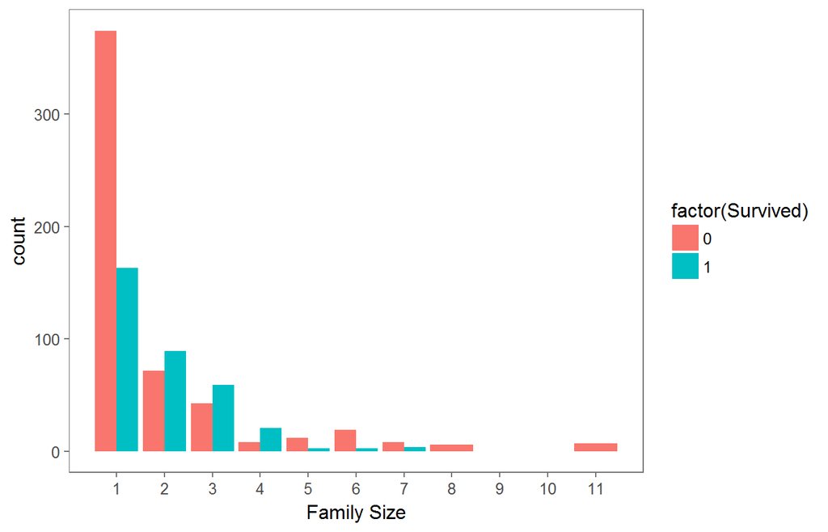

```r
# Use ggplot2 to visualize the relationship between family size & survival
ggplot(full[1:891,], aes(x = FamSize, fill = factor(Survived))) +
  geom_bar(stat='count', position='dodge') +
  scale_x_continuous(breaks=c(1:11)) +
  labs(x = 'Family Size') +
  theme_few()
```

Think I’ll keep FamilySize numeric for now.

```r
numSurvived = sum(train$Survived) # 342
numDied = nrow(train) - numSurvived #549
PropSurvived = numSurvived/nrow(train) # 0.3838384
PropDied = numDied/nrow(train) # 0.6161616
byClass <- group_by(train, Survived, Pclass)
summarise(byClass, train = n())
```

```
## Source: local data frame [6 x 3]
## Groups: Survived [?]
##
##   Survived Pclass train
##      <int>  <int> <int>
## 1        0      1    80
## 2        0      2    97
## 3        0      3   372
## 4        1      1   136
## 5        1      2    87
## 6        1      3   119
```

Based on these numbers, seems like class made a difference to whether or not you survived. Let’s take a look at a visual to make this more clear:

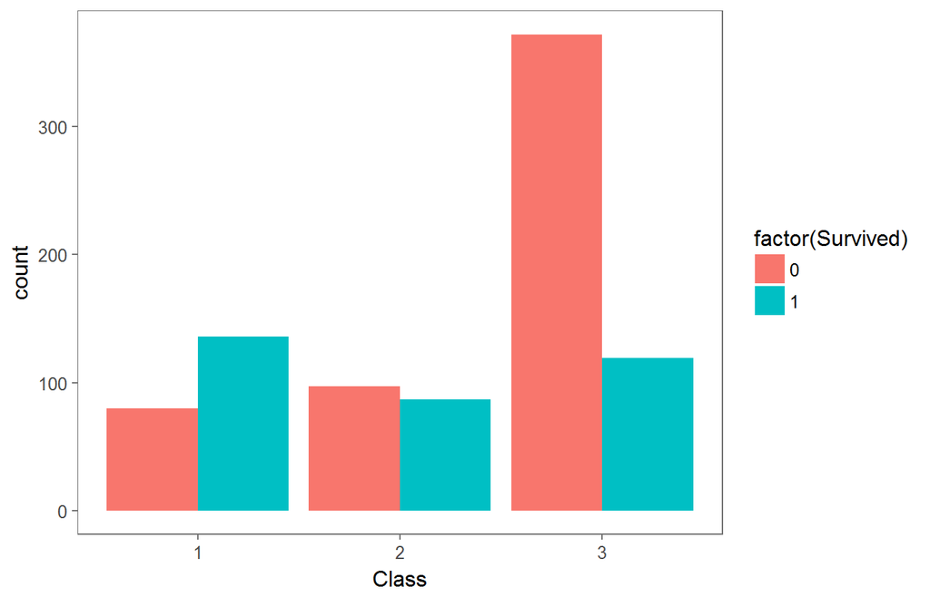

```r
# Use ggplot2 to visualize the relationship between class & survival
ggplot(full[1:891,], aes(x = Pclass, fill = factor(Survived))) +
  geom_bar(stat='count', position='dodge') +
  scale_x_continuous(breaks=c(1:11)) +
  labs(x = 'Class') +
  theme_few()
```

## 2.3 A few tables:

For now let’s look at a few tables like survival by sex and embarked by survived to get a feel for a few other relationships.

```r
# Table for survival by sex
table(train$Survived, train$Sex)
```

```
##
##     female male
##   0     81  468
##   1    233  109
```

```r
table(train$Embarked, train$Survived)
```

```
##
##       0   1
##       0   2
##   C  75  93
##   Q  47  30
##   S 427 217
```

## 2.4 Add indicator columns and engineer a few features:

Then let’s add a few indicator columns missing age and cabin number, and a few columns for the number of characters in the name and ticket, and then the first characters in ticket.

```r
full$Missing_Age = ifelse(is.na(full$Age), 1, 0)
full$Missing_Cabin = ifelse(full$Cabin == "", 1, 0)
full$NumCharName = nchar(full$Name)
full$NumCharTicket <- nchar(full$Ticket)
full$FirstCharTicket<-factor(sapply(full$Ticket, function(x) strsplit(x, NULL)[[1]][1]))
```

# 3 Let’s fix what missing

## 3.1 Missing Embarked

```r
# missing from Embarked
which(full$Embarked == "") # passengers 62 and 830
```

```
## [1]  62 830
```

```r
cat(paste('We will infer their values for **embarkment** based on present data that we can imagine may be relevant:
**passenger class** and **fare**. We see that they paid<b> $', full[c(62, 830), 'Fare'][[1]][1], '</b>and<b> $', full[c(62, 830),
'Fare'][[1]][2], '</b>respectively and their classes are<b>', full[c(62, 830), 'Pclass'][[1]][1], '</b>and<b>', full[c(62, 830),
'Pclass'][[1]][2], '</b>. So from where did they embark?'))
```

We will infer their values for **embarkment** based on present data that we can imagine may be relevant: **passenger class** and **fare**. We see that they paid **$ 80** and **$ NA** respectively and their classes are **1** and **NA** . So from where did they embark?

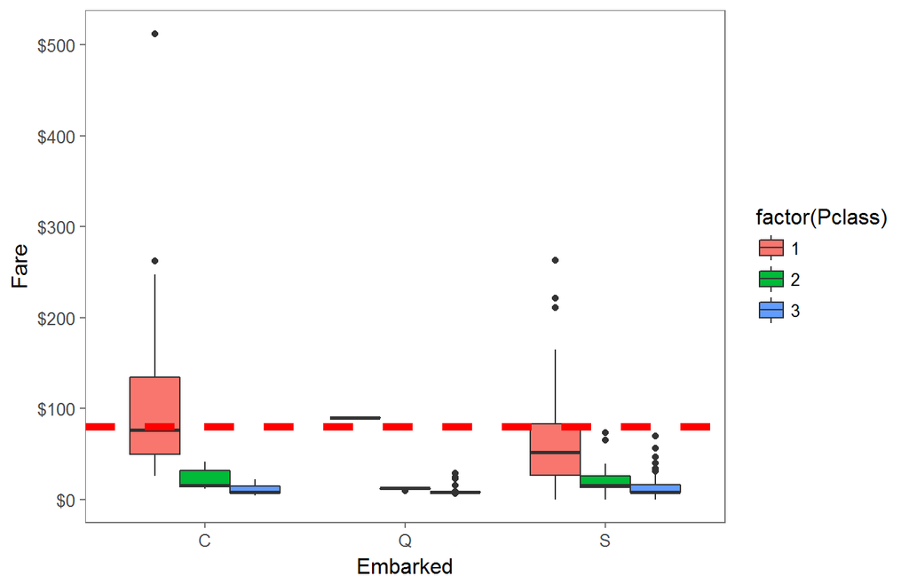

```r
# Get rid of our missing passenger IDs
embark_fare <- full %>%
  filter(PassengerId != 62 & PassengerId != 830)

# Use ggplot2 to visualize embarkment, passenger class, & median fare
ggplot(embark_fare, aes(x = Embarked, y = Fare, fill = factor(Pclass))) +
  geom_boxplot() +
  geom_hline(aes(yintercept=80),
    colour='red', linetype='dashed', lwd=2) +
  scale_y_continuous(labels=dollar_format()) +
  theme_few()
```

Since both passengers with missing values are first class and the fare they both paid is $80 (which is the average fare for those embarking from ‘Charbourg’ it makes sense to assign them both ‘C’ for Embarkment.

```r
# Since their fare was $80 for 1st class, they most likely embarked from 'C'
full$Embarked[c(62, 830)] <- 'C'
```

## 3.2 Missing Fare

```r
# missing from Fare
which(full$Fare == "") # passenger 1044
```

```
## integer(0)
```

```r
# showing the row reveals that this is a 3rd class passenger departing from 'Southampton.'
full[1044, ]
```

```
##      PassengerId Survived Pclass               Name  Sex  Age SibSp Parch
## 1044        1044       NA      3 Storey, Mr. Thomas male 60.5     0     0
##      Ticket Fare Cabin Embarked Title Surname FamSize   Family Missing_Age
## 1044   3701   NA              S    Mr  Storey       1 Storey_1           0
##      Missing_Cabin NumCharName NumCharTicket FirstCharTicket
## 1044             1          18             4               3
```

So let’s look at the distribution of fares for other 3rd class passengers that also departed from Southampton (n = 494).

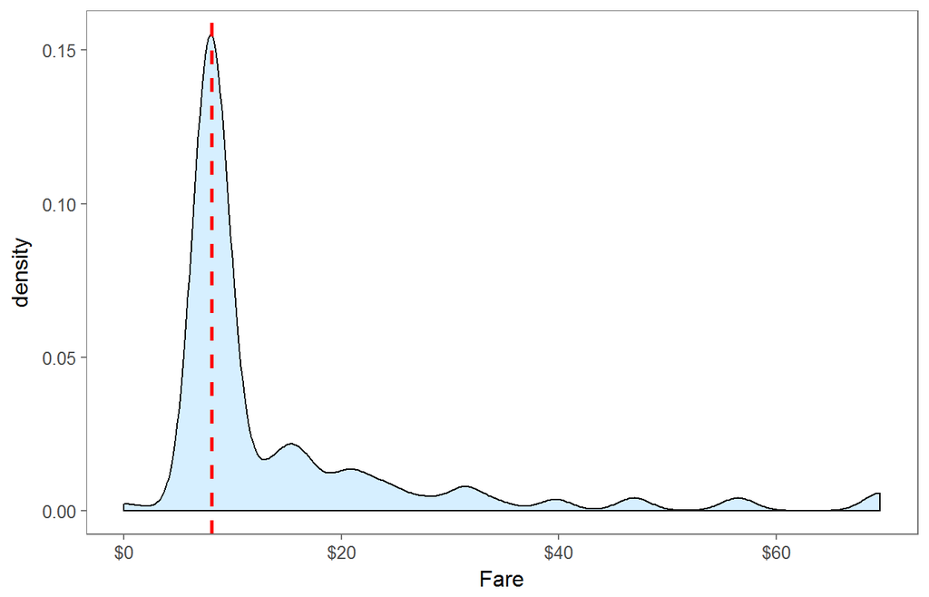

```r
ggplot(full[full$Pclass == '3' & full$Embarked == 'S', ],
  aes(x = Fare)) +
  geom_density(fill = '#99d6ff', alpha=0.4) +
  geom_vline(aes(xintercept=median(Fare, na.rm=T)),
    colour='red', linetype='dashed', lwd=1) +
  scale_x_continuous(labels=dollar_format()) +
  theme_few()
```

Seems fair to replace the NA for this passenger’s fare with the median of the other 3rd class passengers who departed from Southampton which is $8.05.

```r
full$Fare[1044] <- median(full[full$Pclass == '3' & full$Embarked == 'S', ]$Fare, na.rm = TRUE)
```

## 3.3 Missing Age

We know from earlier that there are 263 missing age values

Just for fun, let’s try a few different imputation methods and see what their differences are:

### 3.3.1 Mice imputation

```r
# Make categorical variables into factors
factor_vars <- c('PassengerId','Pclass','Sex','Embarked',
                 'Title','Surname','Family', 'FirstCharTicket')

full[factor_vars] <- lapply(full[factor_vars], function(x) as.factor(x))

# Set a random seed
set.seed(129)

# Perform mice imputation, excluding certain less-than-useful variables:
mice_mod <- mice(full[, !names(full) %in% c('PassengerId','Name','Ticket','Cabin','Family','Surname','Survived', 'FirstCharTicket')], method='rf')
# Save the complete output
mice_output <- complete(mice_mod)
```

Now let’s compare the results we get with the original distribution of passenger ages to see which looks imputation method looks best.

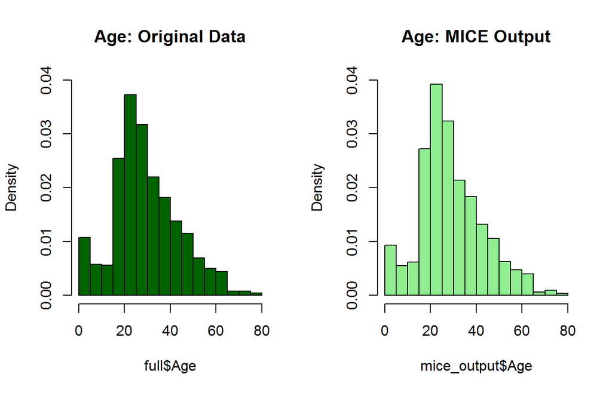

```r
# Plot age distributions
par(mfrow=c(1,2))
hist(full$Age, freq=F, main='Age: Original Data',
  col='darkgreen', ylim=c(0,0.04))
hist(mice_output$Age, freq=F, main='Age: MICE Output',
  col='lightgreen', ylim=c(0,0.04))
```

Things look good, so let’s replace our age vector in the original data with the output from the `mice` model.

```r
# Replace Age variable from the mice model.
full$Age <- mice_output$Age

# Show new number of missing Age values
sum(is.na(full$Age))
```

```
## [1] 0
```

# 4 Prediction

## 4.1 Split into training & test sets

Our first step is to split the data back into the original test and training sets.

```r
# Split the data back into a train set and a test set
train <- full[1:891,]
test <- full[892:1309,]
```

## 4.2 Compare Boosting, Bagging, and Stacking Algorithms

### 4.2.1 Boosting - two of the most popular are C5.0 and Stochastic Gradient Boosting (using Gradient Boosting Modeling implementation)

Note that I’m using the exact same feature variables to train the model as I did with my first Kaggle kernel using the Titanic data for a more direct comparison of the final results (score: .75120)

```r
# Load ensemble libraries we're going to use:
library(mlbench)
library(caret)
library(caretEnsemble)
library(C50)
library(gbm)
library(e1071)

# Example of Boosting Algorithms
control <- trainControl(method="repeatedcv", number=10, repeats=3)
seed <- 1234
metric <- "Accuracy"
# C5.0
set.seed(seed)
fit.c50 <- train(factor(Survived) ~ Pclass + Sex + Age + SibSp + Parch + Fare + Embarked + Title + FamSize + FirstCharTicket + Missing_Age + Missing_Cabin + NumCharName + NumCharTicket, data=train, method="C5.0", metric=metric, trControl=control)
# Stochastic Gradient Boosting
set.seed(seed)
fit.gbm <- train(factor(Survived) ~ Pclass + Sex + Age + SibSp + Parch + Fare + Embarked + Title + FamSize + FirstCharTicket + Missing_Age + Missing_Cabin + NumCharName + NumCharTicket, data=train, method="gbm", metric=metric, trControl=control, verbose=FALSE)
# summarize results
boosting_results <- resamples(list(c5.0=fit.c50, gbm=fit.gbm))
summary(boosting_results)
```

```
##
## Call:
## summary.resamples(object = boosting_results)
##
## Models: c5.0, gbm
## Number of resamples: 30
##
## Accuracy
##        Min. 1st Qu. Median   Mean 3rd Qu.   Max. NA's
## c5.0 0.7191  0.8022 0.8315 0.8286  0.8652 0.9101    0
## gbm  0.7865  0.8095 0.8324 0.8392  0.8652 0.9101    0
##
## Kappa
##        Min. 1st Qu. Median   Mean 3rd Qu.   Max. NA's
## c5.0 0.3734  0.5767 0.6369 0.6302  0.7036 0.8075    0
## gbm  0.5401  0.5908 0.6410 0.6526  0.7095 0.8053    0
```

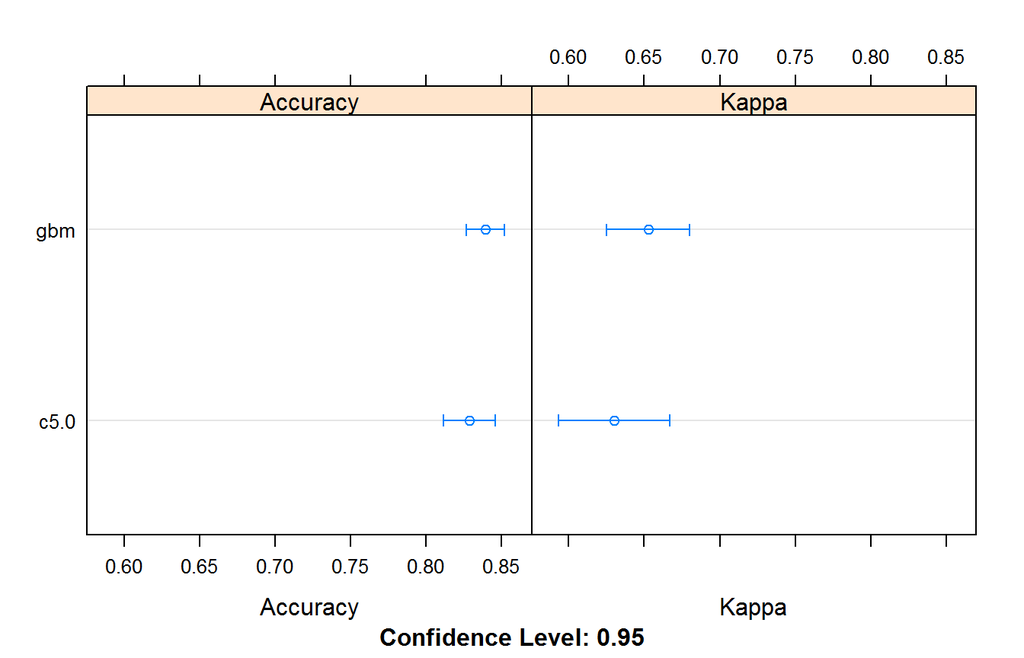

```r
dotplot(boosting_results)
```

We can see that the gbm algorithm produces a more accurate model with an accuracy of 83.92%.

### 4.2.2 Bagging - two of the most popular bagging machine learning algorithms are Bagged CART and Random Forest (which we used in the previous Kaggle kernel but we’re using it differently here so we’ll see what happens)

```r
# load package
library(tree)

# Example of Bagging algorithms
control2 <- trainControl(method="repeatedcv", number=10, repeats=3)
seed <- 1234
metric <- "Accuracy"
# Bagged CART
set.seed(seed)
fit.treebag <- train(factor(Survived) ~ Pclass + Sex + Age + SibSp + Parch + Fare + Embarked + Title + FamSize + FirstCharTicket + Missing_Age + Missing_Cabin + NumCharName + NumCharTicket, data=train, method="treebag", metric=metric, trControl=control2)

# Random Forest
set.seed(seed)
fit.rf <- train(factor(Survived) ~ Pclass + Sex + Age + SibSp + Parch + Fare + Embarked + Title + FamSize + FirstCharTicket + Missing_Age + Missing_Cabin + NumCharName + NumCharTicket, data=train, method="rf", metric=metric, trControl=control2)
# summarize results
bagging_results <- resamples(list(treebag=fit.treebag, rf=fit.rf))
summary(bagging_results)
```

```
##
## Call:
## summary.resamples(object = bagging_results)
##
## Models: treebag, rf
## Number of resamples: 30
##
## Accuracy
##           Min. 1st Qu. Median   Mean 3rd Qu.   Max. NA's
## treebag 0.7528   0.809 0.8315 0.8268  0.8516 0.8989    0
## rf      0.7640   0.809 0.8222 0.8287  0.8516 0.8989    0
##
## Kappa
##           Min. 1st Qu. Median   Mean 3rd Qu.   Max. NA's
## treebag 0.4518  0.5897 0.6284 0.6277   0.677 0.7870    0
## rf      0.4737  0.5833 0.6206 0.6306   0.685 0.7846    0
```

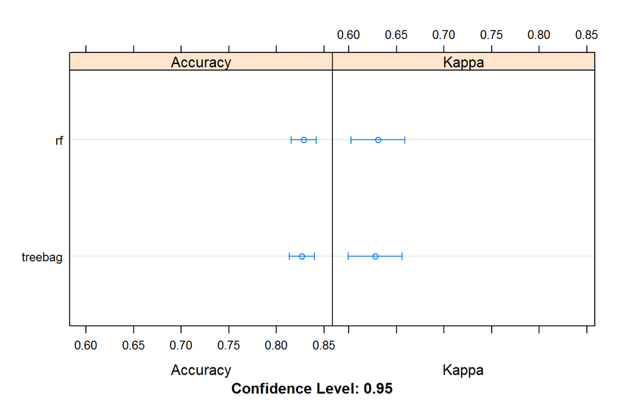

```r
dotplot(bagging_results)
```

We can see that random forest produces a more accurate model with an accuracy of 82.87%.

### 4.2.3 Stacking

- Classification and Regression Trees (CART)
- Logistic Regression (via Generalized Linear Model or GLM)
- k-Nearest Neighbors (kNN)
- Support Vector Machine with a Radial Basis Kernel Function (SVM)

The following creates these 4 sub-models using the helpful caretList() function.

```r
# Example of Stacking algorithms

# Load packages
library(rpart) # for CART
library(kernlab) # for knn

# Make sure feature variable names are in correct format to avoid error when setting classProbs=TRUE in trainControl function below:
feature.names=names(train$Survived)
for (f in feature.names) {
    if (class(train[[f]])=="factor") {
        levels <- unique(c(train[[f]]))
        train[[f]] <- factor(train[[f]],
                             labels=make.names(levels))
 }
}

levels <- unique(train$Survived)
train$Survived <- factor(train$Survived, labels=make.names(levels))

# create submodels
control3 <- trainControl(method="repeatedcv", number=10, repeats=3, savePredictions=TRUE, classProbs=TRUE)
algorithmList <- c('rpart', 'glm', 'knn', 'svmRadial')
set.seed(seed)
models <- caretList(Survived ~ Pclass + factor(Sex) + Age + SibSp + Parch + Fare + factor(Embarked) + factor(Title) + FamSize + factor(FirstCharTicket) + Missing_Age + Missing_Cabin + NumCharName + NumCharTicket, data=train, trControl=control3,  methodList=algorithmList)
results <- resamples(models)
summary(results)
```

```
##
## Call:
## summary.resamples(object = results)
##
## Models: rpart, glm, knn, svmRadial
## Number of resamples: 30
##
## Accuracy
##             Min. 1st Qu. Median   Mean 3rd Qu.   Max. NA's
## rpart     0.7614  0.7865 0.7989 0.8081  0.8315 0.8764    0
## glm       0.7273  0.8095 0.8305 0.8283  0.8539 0.8989    0
## knn       0.6404  0.7191 0.7416 0.7415  0.7753 0.8202    0
## svmRadial 0.6556  0.8090 0.8427 0.8272  0.8551 0.9101    0
##
## Kappa
##             Min. 1st Qu. Median   Mean 3rd Qu.   Max. NA's
## rpart     0.4940  0.5160 0.5662 0.5826  0.6462 0.7426    0
## glm       0.4310  0.5923 0.6410 0.6327  0.6911 0.7796    0
## knn       0.2195  0.3879 0.4401 0.4393  0.5187 0.6149    0
## svmRadial 0.2715  0.5813 0.6531 0.6271  0.6875 0.8075    0
```

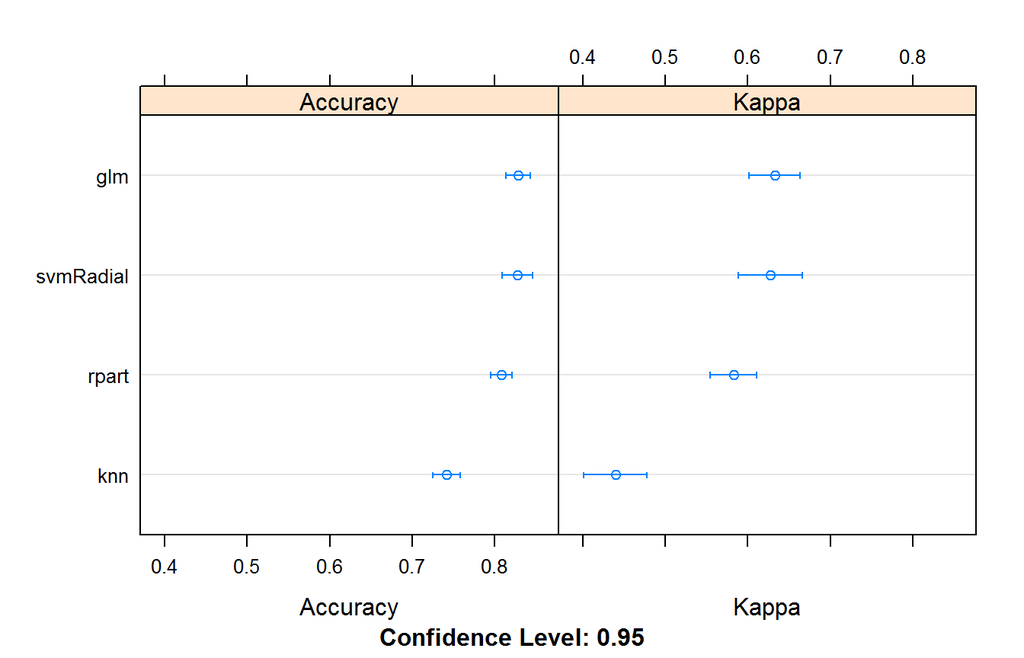

```r
dotplot(results)
```

When it comes to stacking different models, it is best to use models that have low correlation since it suggests each model is contributing to the overall accuracy but in different ways. The benefits of combining models is reduced if their correlations are highly correlated (>.75).

```r
# correlation between results
modelCor(results)
```

```
##               rpart       glm       knn svmRadial
## rpart     1.0000000 0.5196901 0.4232688 0.2943422
## glm       0.5196901 1.0000000 0.3757402 0.4072204
## knn       0.4232688 0.3757402 1.0000000 0.3825430
## svmRadial 0.2943422 0.4072204 0.3825430 1.0000000
```

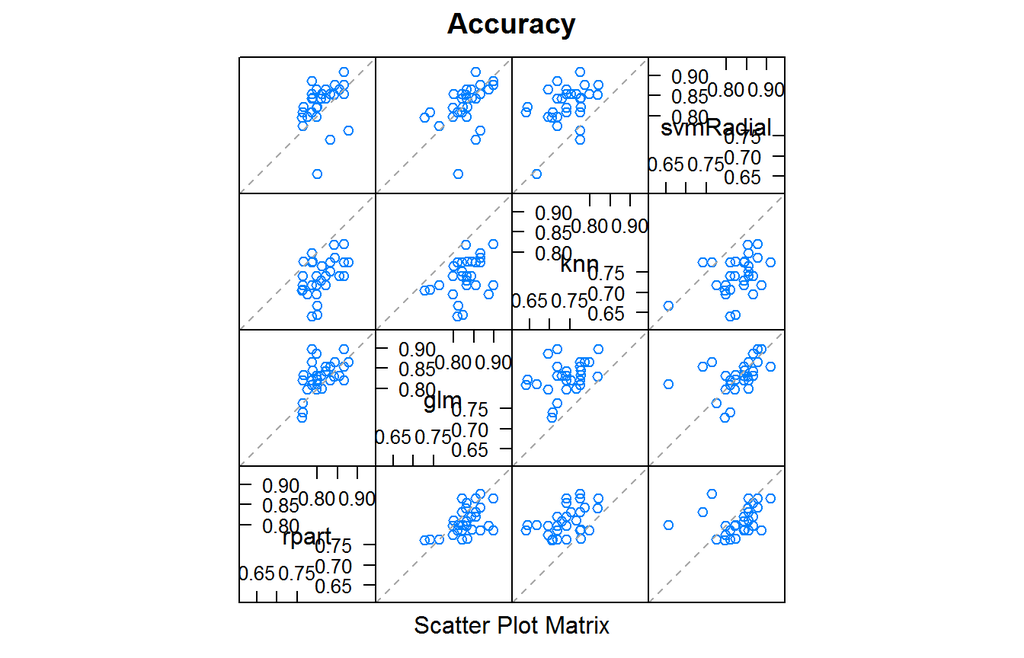

```r
splom(results)
```

Now let’s combine the predictions using a linear model.

```r
# stack using glm
stackControl <- trainControl(method="repeatedcv", number=10, repeats=3, savePredictions=TRUE, classProbs=TRUE)
set.seed(seed)
stack.glm <- caretStack(models, method="glm", metric="Accuracy", trControl=stackControl)
print(stack.glm)
```

```
## A glm ensemble of 2 base models: rpart, glm, knn, svmRadial
##
## Ensemble results:
## Generalized Linear Model
##
## 2673 samples
##    4 predictor
##    2 classes: 'X0', 'X1'
##
## No pre-processing
## Resampling: Cross-Validated (10 fold, repeated 3 times)
## Summary of sample sizes: 2406, 2405, 2406, 2406, 2405, 2406, ...
## Resampling results:
##
##   Accuracy   Kappa
##   0.8315271  0.637399
##
##
```

We can see that we have lifted the accuracy to 83.15% which is a small improvement over using SVM alone. This is also an improvement over using random forest alone on the dataset, as observed above.

We can also use more sophisticated algorithms to combine predictions in an effort to tease out when best to use the different methods. In this case, we can use the random forest algorithm to combine the predictions.

```r
# stack using random forest
set.seed(seed)
stack.rf <- caretStack(models, method="rf", metric="Accuracy", trControl=stackControl)
print(stack.rf)
```

```
## A rf ensemble of 2 base models: rpart, glm, knn, svmRadial
##
## Ensemble results:
## Random Forest
##
## 2673 samples
##    4 predictor
##    2 classes: 'X0', 'X1'
##
## No pre-processing
## Resampling: Cross-Validated (10 fold, repeated 3 times)
## Summary of sample sizes: 2406, 2405, 2406, 2406, 2405, 2406, ...
## Resampling results across tuning parameters:
##
##   mtry  Accuracy   Kappa
##   2     0.8468629  0.6694206
##   3     0.8462429  0.6682841
##   4     0.8461180  0.6686165
##
## Accuracy was used to select the optimal model using  the largest value.
## The final value used for the model was mtry = 2.
```

We can see that this has lifted the accuracy to 84.69% a nice improvement on SVM alone.

## 4.3 Confusion Matrix

Let’s measure the performance of the random forest stack by generating a confusion matrix:

```r
# Note that 'X0' corresponds to 'Died'
confusionMatrix(data = stack.rf$ens_model$pred$pred, reference = stack.rf$ens_model$pred$obs)
```

```
## Confusion Matrix and Statistics
##
##           Reference
## Prediction    X0    X1
##         X0 13448  2320
##         X1  1375  6914
##
##                Accuracy : 0.8464
##                  95% CI : (0.8418, 0.8509)
##     No Information Rate : 0.6162
##     P-Value [Acc > NIR] : < 2.2e-16
##
##                   Kappa : 0.6689
##  Mcnemar's Test P-Value : < 2.2e-16
##
##             Sensitivity : 0.9072
##             Specificity : 0.7488
##          Pos Pred Value : 0.8529
##          Neg Pred Value : 0.8341
##              Prevalence : 0.6162
##          Detection Rate : 0.5590
##    Detection Prevalence : 0.6554
##       Balanced Accuracy : 0.8280
##
##        'Positive' Class : X0
##
```

## 4.4 Prediction

```r
# Predict using the test set
prediction <- predict(stack.rf, test)

# change Survived factors back to numeric prior to predicting:
prediction <- ifelse(prediction == "X0", 0, 1)

# Save the solution to a dataframe with two columns: PassengerId and Survived (prediction)
solution <- data.frame(PassengerID = test$PassengerId, Survived = prediction)

# Write the solution to file
write.csv(solution, file = 'stack.rf_Solution.csv', row.names = F)
```

# 5 Conclusion

Stacking models can make a considerable improvement over single models!